# ECS530: Spatial data analysis I

Roger Bivand

20 September - 4 October 2022

### Copyright

All the material presented here, to the extent it is original, is available under [CC-BY-SA](https://creativecommons.org/licenses/by-sa/4.0/).

## Preparatory

Most of the materials share a “reproducible” structure, with the web documents being generated from “notebooks,” earlier `Sweave` documents with R code embedded in LaTeX source, and pre-processed to insert the code and output into the document before rendering to for example PDF. Since Rstudio and the **knitr** package became available, the R markdown format has become established - the new Quarto format (`.qmd`, for our purposes just like `.Rmd`) is now also sometimes seen.

This means that when watching a video, you should be able to have downloaded the presentation, the code, and any required data sets. The same model applies to articles published in the R Journal http://journal.r-project.org/ and Journal of Statistical Software https://www.jstatsoft.org/index. This should mean that you can run the code (for example in Rstudio) at the same time as you view the video, and/or presentation document/slides. Maybe watch the video on a phone or tablet if your laptop screen is cramped. The idea is not to treat videos, articles or book chapters as one-way communication only, but to be actively engaged with the code generating the output.

Note that current versions of packages may not behave exactly like the versions used for generating the original output. In https://doi.org/10.1007/s10109-020-00336-0, a codechecking system and zenodo timestamping were used to certify that the then status of https://github.com/rsbivand/JGSY-D-19-00087 matched the output, but in most cases, like https://doi.org/10.1111/gean.12319, just a repo (repository) is given: https://github.com/rsbivand/gaSI21 with a zenodo stamp.

The latter and a manuscript “Analytical Environments” also mention Python workflows leading to similar outcomes as the R workflows.

Please also note that spatial data analysis in R evolves over time as package “niches” adapt to changes in underlying software. Please for example see a recent FOSS4G workshop (Free and Open Source Software for Geospatial): https://rsbivand.github.io/foss4g_2022/modernizing_220822.html. Core spatial R packages depend on key external C++ libraries, these libraries also evolve (the so-called “barn-raising” project), and older workflows either stop working or behave differently. This means that it is helpful to be aware that change happens, and thus that web searches for solutions to problems often lead to outdated apparent advice (especially as search results are not ranked by date newest first but by number of links and visits, very often oldest first). Jakub Nowosad’s OpenGeoHub talk gives a good picture of this.

## Materials

Within Canvas (NHH’s portal for courses), access to published written material is through Leganto. This goes via an proxy library link with the same login as Canvas, which gives library access to otherwise restricted references. Some of these are also open access, which means that even without Canvas access, some materials are available, and others may be available without access if participants’ affiliations give local library access to restricted references. Access via Canvas and Leganto is certainly preferable.

Scripts and materials from earlier editions of ECS530 are on Github, as is the case for this edition.

Videos from ECS530 2020 (last recorded edition, recordings from zoom) are available in Canvas with one exception https://www.youtube.com/watch?v=2H1Tn4oN32M, complemented by materials on github: https://rsbivand.github.io/ECS530_h20/; from 2019 (classroom recordings) are on the OpenGeoHub YouTube channel https://www.youtube.com/playlist?list=PLXUoTpMa_9s10NVk4dBQljNOaOXAOhcE0, complemented by materials on github: https://rsbivand.github.io/ECS530_h19/. Recordings of conference talks, webinars and panels are openly available.

Materials in Canvas also include a module of “Other materials” with links to webinars, conference talks, etc. - other links are being added, and an “R introduction” module with short videos on using R.

For recent introductions, Paula Moraga’s useR! 2022 keynote (https://www.youtube.com/watch?v=wif3dmkUs5o&list=PL77T87Q0eoJi2VLI8HHVA08m1d5zfQsWJ&index=1), and/or Jakub Nowosad’s OpenGeoHub 2022 talk (https://www.youtube.com/watch?v=a4imsVqbGY0, https://jakubnowosad.com/ogh2022) may be useful. Both of these scholars are authors in open-access book projects: https://geocompr.robinlovelace.net/index.html, https://www.paulamoraga.com/book-geospatial-info/. Many articles are also now published open-access.

## Representing and visualizing spatial data

This is a “flipped” module, and admits varying speeds and choices. The first 9 chapters of https://geocompr.robinlovelace.net/index.html, chapter 2 of https://www.paulamoraga.com/book-geospatial-info/, and or the first 9 chapters of https://keen-swartz-3146c4.netlify.app/ (a fresher version should be online soon) complement the first two days of ECS530 2019-2021. They cover similar topics, overlap in places, and sometimes differ in the weight given to different topics. https://paezha.github.io/spatial-analysis-r/ is another choice, complementing geocompr, with more structured learning objectives. All of these open-access book projects invite your contributions, and foster the development of non-competitive communities where authority is earned by being able to show through code how tasks may be carried out.

The learning process should kick-off now by discussion of how you, course participants, can assist each other in working. Please feel free to set up reading groups, to split up topics between yourselves to give reasonable coverage, and, crucially, share data sets (they can be data sets from **spData** and **spDataLarge**) and code to show how to do things, including data import/export, data manipuation and visualization.

The representation of spatial data is non-trivial, as this figure by Peter Burrough, one of the founders of geographical information systems, shows:

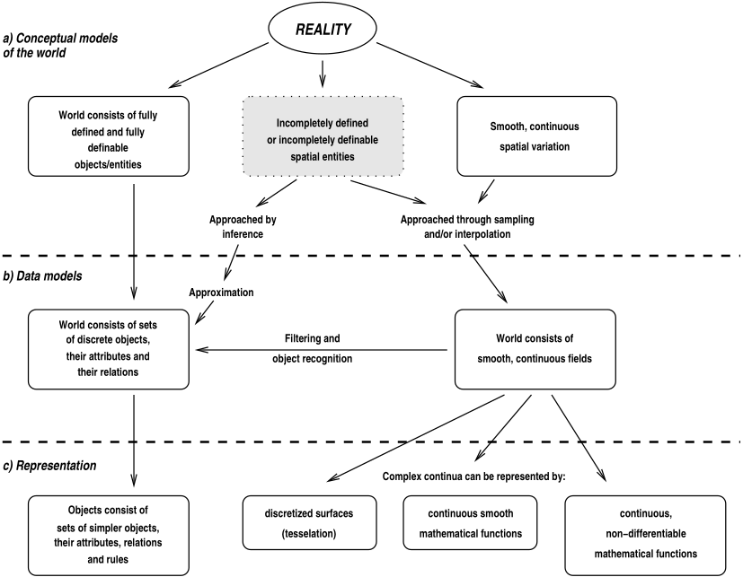

There are aspects of reality that our data models cannot capture, and there are then aspects of the data models that our data representation cannot capture. We can represent aspects of reality, but our operationalised measurements are not reality. One problem is that maps are not reality (fixed in time, two-dimensional), another that we often observe or measure variables which only proxy the concepts we are trying to study.

[figure not shown]